# Human Resources Analytics

### Imported All the necessary libraries:

```python
import numpy as np
import pandas as pd
import matplotlib.pyplot as plt
import seaborn as sns
from sklearn.preprocessing import StandardScaler
from sklearn.model_selection import train_test_split

from sklearn.ensemble import RandomForestClassifier
from sklearn.svm import SVC
from sklearn.ensemble import GradientBoostingClassifier
from sklearn.metrics import accuracy_score, confusion_matrix, classification_report
from sklearn.model_selection import GridSearchCV
```

### Read the Data set and store it in a pandas Data Frame:

```python
df = pd.read_csv("Human_Resuorces_Analytics.csv")
```

### How many rows and columns in the data frame :

```python
df.shape
```

```
(311, 36)
```

### Explore the names of columns in the data frame:

```python
df.columns
```

```
Index(['Employee_Name', 'EmpID', 'MarriedID', 'MaritalStatusID', 'GenderID',
       'EmpStatusID', 'DeptID', 'PerfScoreID', 'FromDiversityJobFairID',
       'Salary', 'Termd', 'PositionID', 'Position', 'State', 'Zip', 'DOB',
       'Sex', 'MaritalDesc', 'CitizenDesc', 'HispanicLatino', 'RaceDesc',
       'DateofHire', 'DateofTermination', 'TermReason', 'EmploymentStatus',
       'Department', 'ManagerName', 'ManagerID', 'RecruitmentSource',
       'PerformanceScore', 'EngagementSurvey', 'EmpSatisfaction',
       'SpecialProjectsCount', 'LastPerformanceReview_Date', 'DaysLateLast30',
       'Absences'],
      dtype='object')
```

### General Information About the Columns of the Data Frame :

```python
df.info()
```

```
<class 'pandas.core.frame.DataFrame'>
RangeIndex: 311 entries, 0 to 310
Data columns (total 36 columns):
 #   Column                      Non-Null Count  Dtype
---  ------                      --------------  -----
 0   Employee_Name               311 non-null    object
 1   EmpID                       311 non-null    int64
 2   MarriedID                   311 non-null    int64
 3   MaritalStatusID             311 non-null    int64
 4   GenderID                    311 non-null    int64
 5   EmpStatusID                 311 non-null    int64
 6   DeptID                      311 non-null    int64
 7   PerfScoreID                 311 non-null    int64
 8   FromDiversityJobFairID      311 non-null    int64
 9   Salary                      311 non-null    int64
```

[output cut: 28 more lines]

### Display the first 10 rows of data frame:

```python
df.head(10)
```

|  | Employee_Name | EmpID | MarriedID | MaritalStatusID | GenderID | EmpStatusID | DeptID | PerfScoreID | FromDiversityJobFairID | Salary | ... | ManagerName | ManagerID | RecruitmentSource | PerformanceScore | EngagementSurvey | EmpSatisfaction | SpecialProjectsCount | LastPerformanceReview_Date | DaysLateLast30 | Absences |
| --- | --- | --- | --- | --- | --- | --- | --- | --- | --- | --- | --- | --- | --- | --- | --- | --- | --- | --- | --- | --- | --- |
| 0 | Adinolfi, Wilson K | 10026 | 0 | 0 | 1 | 1 | 5 | 4 | 0 | 62506 | ... | Michael Albert | 22.0 | LinkedIn | Exceeds | 4.60 | 5 | 0 | 1/17/2019 | 0 | 1 |
| 1 | Ait Sidi, Karthikeyan | 10084 | 1 | 1 | 1 | 5 | 3 | 3 | 0 | 104437 | ... | Simon Roup | 4.0 | Indeed | Fully Meets | 4.96 | 3 | 6 | 2/24/2016 | 0 | 17 |
| 2 | Akinkuolie, Sarah | 10196 | 1 | 1 | 0 | 5 | 5 | 3 | 0 | 64955 | ... | Kissy Sullivan | 20.0 | LinkedIn | Fully Meets | 3.02 | 3 | 0 | 5/15/2012 | 0 | 3 |
| 3 | Alagbe,Trina | 10088 | 1 | 1 | 0 | 1 | 5 | 3 | 0 | 64991 | ... | Elijiah Gray | 16.0 | Indeed | Fully Meets | 4.84 | 5 | 0 | 1/3/2019 | 0 | 15 |
| 4 | Anderson, Carol | 10069 | 0 | 2 | 0 | 5 | 5 | 3 | 0 | 50825 | ... | Webster Butler | 39.0 | Google Search | Fully Meets | 5.00 | 4 | 0 | 2/1/2016 | 0 | 2 |
| 5 | Anderson, Linda | 10002 | 0 | 0 | 0 | 1 | 5 | 4 | 0 | 57568 | ... | Amy Dunn | 11.0 | LinkedIn | Exceeds | 5.00 | 5 | 0 | 1/7/2019 | 0 | 15 |
| 6 | Andreola, Colby | 10194 | 0 | 0 | 0 | 1 | 4 | 3 | 0 | 95660 | ... | Alex Sweetwater | 10.0 | LinkedIn | Fully Meets | 3.04 | 3 | 4 | 1/2/2019 | 0 | 19 |
| 7 | Athwal, Sam | 10062 | 0 | 4 | 1 | 1 | 5 | 3 | 0 | 59365 | ... | Ketsia Liebig | 19.0 | Employee Referral | Fully Meets | 5.00 | 4 | 0 | 2/25/2019 | 0 | 19 |
| 8 | Bachiochi, Linda | 10114 | 0 | 0 | 0 | 3 | 5 | 3 | 1 | 47837 | ... | Brannon Miller | 12.0 | Diversity Job Fair | Fully Meets | 4.46 | 3 | 0 | 1/25/2019 | 0 | 4 |
| 9 | Bacong, Alejandro | 10250 | 0 | 2 | 1 | 1 | 3 | 3 | 0 | 50178 | ... | Peter Monroe | 7.0 | Indeed | Fully Meets | 5.00 | 5 | 6 | 2/18/2019 | 0 | 16 |

10 rows × 36 columns

### What are the data types of the columns in the data frame:

```python
df.dtypes
```

```
Employee_Name                  object
EmpID                           int64
MarriedID                       int64
MaritalStatusID                 int64
GenderID                        int64
EmpStatusID                     int64
DeptID                          int64
PerfScoreID                     int64
FromDiversityJobFairID          int64
Salary                          int64
Termd                           int64
PositionID                      int64
Position                       object
State                          object
Zip                             int64
DOB                            object
Sex                            object
MaritalDesc                    object
CitizenDesc                    object
HispanicLatino                 object
RaceDesc                       object
DateofHire                     object
DateofTermination              object
TermReason                     object
EmploymentStatus               object
Department                     object
ManagerName                    object
ManagerID                     float64
RecruitmentSource              object
PerformanceScore               object
EngagementSurvey              float64
EmpSatisfaction                 int64
SpecialProjectsCount            int64
LastPerformanceReview_Date     object
DaysLateLast30                  int64
Absences                        int64
dtype: object
```

### Check the missing values in the columns of the data frame:

```python
df.isnull().any()
```

```
Employee_Name                 False
EmpID                         False
MarriedID                     False
MaritalStatusID               False
GenderID                      False
EmpStatusID                   False
DeptID                        False
PerfScoreID                   False
FromDiversityJobFairID        False
Salary                        False
Termd                         False
PositionID                    False
Position                      False
State                         False
Zip                           False
DOB                           False
Sex                           False
MaritalDesc                   False
CitizenDesc                   False
HispanicLatino                False
RaceDesc                      False
DateofHire                    False
DateofTermination              True
TermReason                    False
EmploymentStatus              False
Department                    False
ManagerName                   False
ManagerID                      True
RecruitmentSource             False
PerformanceScore              False
EngagementSurvey              False
EmpSatisfaction               False
SpecialProjectsCount          False
LastPerformanceReview_Date    False
DaysLateLast30                False
Absences                      False
dtype: bool
```

### Count the missing values in the columns of the data frame:

```python
df.isnull().sum()
```

```
Employee_Name                   0
EmpID                           0
MarriedID                       0
MaritalStatusID                 0
GenderID                        0
EmpStatusID                     0
DeptID                          0
PerfScoreID                     0
FromDiversityJobFairID          0
Salary                          0
Termd                           0
PositionID                      0
Position                        0
State                           0
Zip                             0
DOB                             0
Sex                             0
MaritalDesc                     0
CitizenDesc                     0
HispanicLatino                  0
RaceDesc                        0
DateofHire                      0
DateofTermination             207
TermReason                      0
EmploymentStatus                0
Department                      0
ManagerName                     0
ManagerID                       8
RecruitmentSource               0
PerformanceScore                0
EngagementSurvey                0
EmpSatisfaction                 0
SpecialProjectsCount            0
LastPerformanceReview_Date      0
DaysLateLast30                  0
Absences                        0
dtype: int64
```

# Section A (Data Exploration and Pre-processing):

### Explore the data using tables, visualizations, and other relevant methods

### 1. Overall Diversity Profile of the Organization:

To understand the diversity profile of the organization, we can analyze the distribution of employees based on their gender and ethnicity. We'll create a bar plot to visualize this

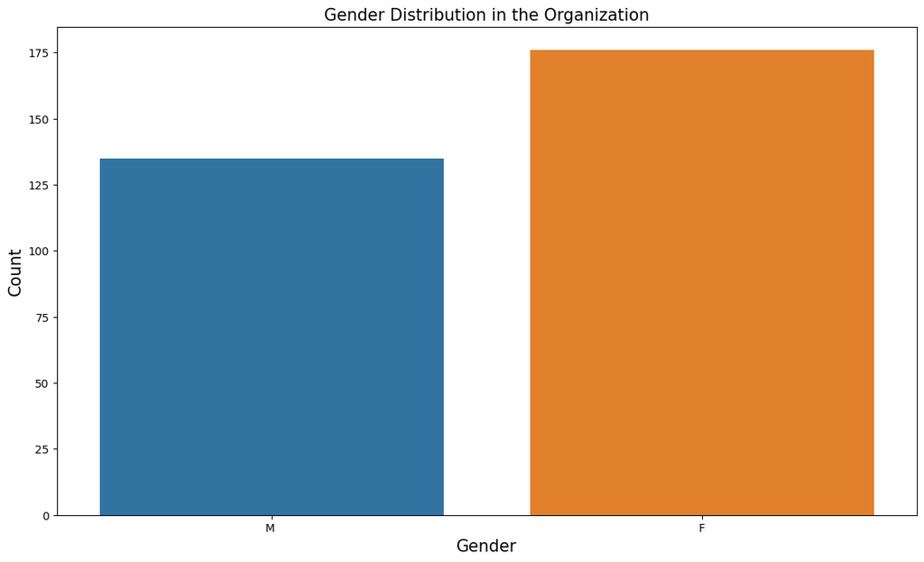

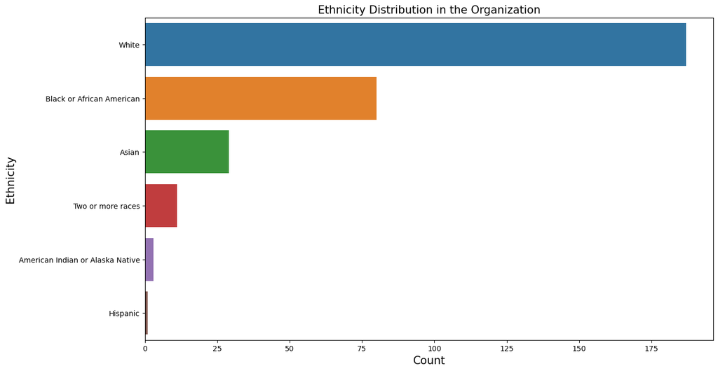

```python
# Count the number of employees in each gender category
gender_counts = df['Sex'].value_counts()

# Count the number of employees based on their ethnicity
ethnicity_counts = df['RaceDesc'].value_counts()

# Plot the gender distribution
plt.figure(figsize=(14, 8))
sns.countplot(data=df, x='Sex')
plt.title('Gender Distribution in the Organization', fontsize = 15)
plt.xlabel('Gender', fontsize = 15)
plt.ylabel('Count', fontsize = 15)
plt.show()

# Plot the ethnicity distribution
plt.figure(figsize=(14, 8))
sns.countplot(data=df, y='RaceDesc', order=ethnicity_counts.index)
plt.title('Ethnicity Distribution in the Organization', fontsize = 15)
plt.xlabel('Count', fontsize = 15)
plt.ylabel('Ethnicity', fontsize = 15)
plt.show()
```

These plots will provide insights into the gender and ethnicity diversity within the organization.

### 2. Relationship between Manager and Performance Score:

We can investigate whether there is any relationship between the employee's manager and their performance score. To visualize this, we'll use a box plot to compare the performance scores across different managers.

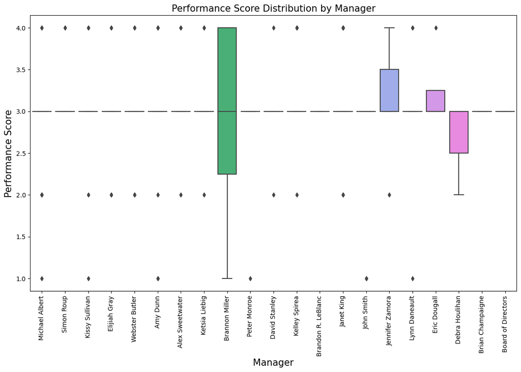

```python
plt.figure(figsize=(14, 8))
sns.boxplot(data=df, x='ManagerName', y='PerfScoreID')
plt.xticks(rotation=90)
plt.title('Performance Score Distribution by Manager', fontsize = 15)
plt.xlabel('Manager', fontsize = 15)
plt.ylabel('Performance Score', fontsize = 15)
plt.show()
```

This box plot will help us identify any variations in performance scores based on the employee's manager.

### 3. Areas of Pay Inequity:

To identify areas of pay inequity within the company, we can compare the salaries across different departments. A violin plot can effectively showcase the distribution of salaries in each department.

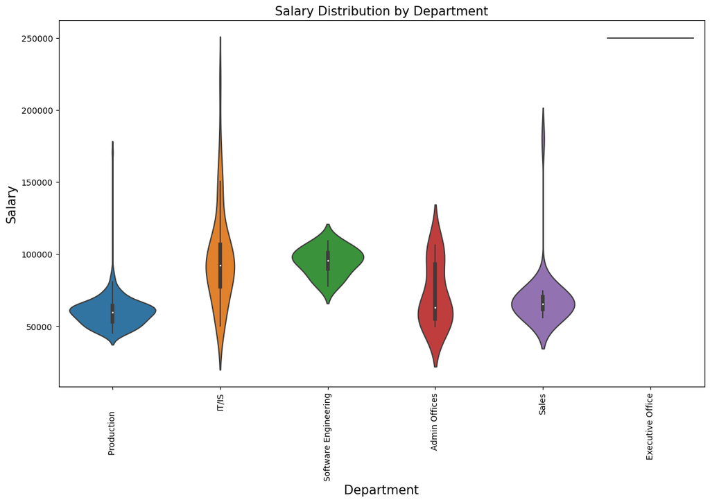

```python
plt.figure(figsize=(14, 8))
sns.violinplot(data=df, x='Department', y='Salary')
plt.xticks(rotation=90)
plt.title('Salary Distribution by Department', fontsize = 15)
plt.xlabel('Department', fontsize = 15)
plt.ylabel('Salary', fontsize = 15)
plt.show()
```

This visualization will highlight any variations in salary distribution across different departments, indicating potential areas of pay inequity.

### 4. Employee Satisfaction and Engagement Survey by Performance Score:

Let's create a scatter plot to visualize the relationship between employee satisfaction, engagement survey results, and performance scores. This will help us understand if there are any patterns or correlations among these variables.

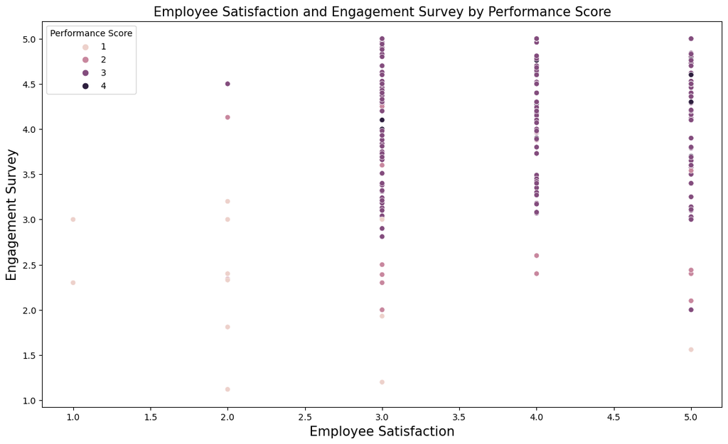

```python
plt.figure(figsize=(14, 8))
sns.scatterplot(data=df, x='EmpSatisfaction', y='EngagementSurvey', hue='PerfScoreID')
plt.title('Employee Satisfaction and Engagement Survey by Performance Score', fontsize = 15)
plt.xlabel('Employee Satisfaction', fontsize = 15)
plt.ylabel('Engagement Survey', fontsize = 15)
plt.legend(title='Performance Score')
plt.show()
```

This scatter plot will show how employee satisfaction and engagement survey results vary across different performance scores.

### 5. Salary Distribution by Department and Performance Score:

Let's visualize the distribution of salaries across different departments, considering the performance scores of employees as well. We'll use a box plot with color encoding to represent the performance scores.

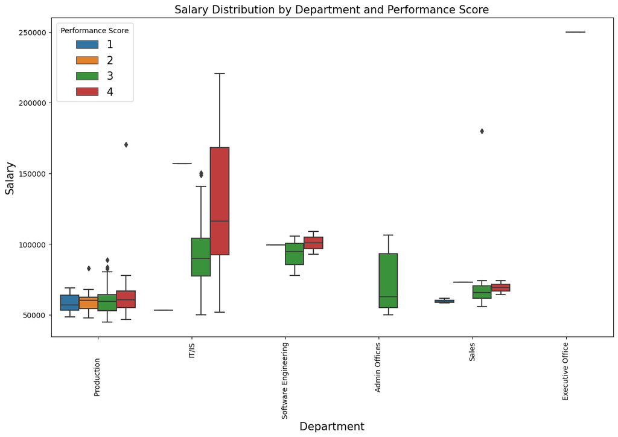

```python
plt.figure(figsize=(14, 8))
sns.boxplot(data=df, x='Department', y='Salary', hue='PerfScoreID')
plt.xticks(rotation=90)
plt.title('Salary Distribution by Department and Performance Score', fontsize = 15)
plt.xlabel('Department', fontsize = 15)
plt.ylabel('Salary', fontsize = 15)
plt.legend(title='Performance Score', fontsize = 15)
plt.show()
```

In this plot, each box represents the salary distribution for a specific department, and the color of the boxes represents different performance scores. This allows us to simultaneously explore the salary distributions and performance scores across departments.

1) Overall Diversity Profile of the Organization:

- The gender distribution graph provides insights into the gender diversity within the organization.
- The ethnicity distribution graph offers an understanding of the ethnic diversity within the organization.
- These graphs can help us assess the overall diversity profile of the organization.

2) Relationship between Who a Person Works for and Their Performance Score:

- The box plot graph comparing performance scores across different managers provides insights into the potential relationship between an employee's manager and their performance score.
- This graph allows us to explore whether there is any correlation between the employee's manager and their performance score.

3) Areas of the Company Where Pay Is Not Equitable:

- The violin plot graph displaying the salary distribution by department can help identify potential areas where pay may not be equitable. This graph enables us to visually assess variations in salary distribution across different departments, indicating areas where pay inequity might exist.

### Apply different methods of pre-processing

### Handling the missing values in ManagerID column:

```python
df['ManagerID'] = df['ManagerID'].fillna(df['ManagerID'].median())
```

```python
df['DateofTermination'] = df['DateofTermination'].fillna(df['DateofTermination'].mode()[0])
```

### Convert date columns to datetime data type:

```python
df['DOB'] = pd.to_datetime(df['DOB'])
df['DateofHire'] = pd.to_datetime(df['DateofHire'])
df['DateofTermination'] = pd.to_datetime(df['DateofTermination'])
df['LastPerformanceReview_Date'] = pd.to_datetime(df['LastPerformanceReview_Date'])
```

### Replace 'no' and 'yes' with 'No' and 'Yes' in HispanicLatino column:

```python
df['HispanicLatino'] = df['HispanicLatino'].str.replace('no', 'No').replace('yes','Yes')
```

### Create some new columns: AgeAtHire, EmploymentDuration , TimeSinceLastReview and TimeUntilTermination from date columns in the data frame:

```python
# Calculate age at hire
df['AgeAtHire'] = (df['DateofHire'] - df['DOB']).dt.days // 365

# Calculate employment duration
df['EmploymentDuration'] = (df['DateofTermination'].fillna(pd.Timestamp.now()) - df['DateofHire']).dt.days

# Calculate time since last performance review
df['TimeSinceLastReview'] = (pd.Timestamp.now() - df['LastPerformanceReview_Date']).dt.days

# Calculate the time difference in days
df['TimeUntilTermination'] = abs((df['DateofTermination'].fillna(pd.Timestamp.now()) - df['LastPerformanceReview_Date']).dt.days)

last_performance_dates = df['LastPerformanceReview_Date']

# Drop the original date columns
df.drop(['DOB', 'DateofHire', 'DateofTermination', 'LastPerformanceReview_Date'], axis=1, inplace=True)
```

### Drop some unnecessary columns from data frame:</h3 >

```python
df.drop(['Employee_Name','Position','State','TermReason','EmpStatusID', 'Department','MaritalDesc','EmpID', 'Zip',  'ManagerName'], axis = 1, inplace = True)
```

### Convert the values of categorical columns to numeric columns:

```python
df['Sex'] = df['Sex'].astype('category').cat.codes
df['CitizenDesc'] = df['CitizenDesc'].astype('category').cat.codes
df['HispanicLatino'] = df['HispanicLatino'].astype('category').cat.codes
df['RaceDesc'] = df['RaceDesc'].astype('category').cat.codes
df['RecruitmentSource'] = df['RecruitmentSource'].astype('category').cat.codes
df['PerformanceScore'] = df['PerformanceScore'].astype('category').cat.codes
#df['EmploymentStatus'] = df['EmploymentStatus'].astype('category').cat.codes
```

### Display the updated dataset with the new features

```python
df.head(10)
```

|  | MarriedID | MaritalStatusID | GenderID | DeptID | PerfScoreID | FromDiversityJobFairID | Salary | Termd | PositionID | Sex | ... | PerformanceScore | EngagementSurvey | EmpSatisfaction | SpecialProjectsCount | DaysLateLast30 | Absences | AgeAtHire | EmploymentDuration | TimeSinceLastReview | TimeUntilTermination |
| --- | --- | --- | --- | --- | --- | --- | --- | --- | --- | --- | --- | --- | --- | --- | --- | --- | --- | --- | --- | --- | --- |
| 0 | 0 | 0 | 1 | 5 | 4 | 0 | 62506 | 0 | 19 | 1 | ... | 0 | 4.60 | 5 | 0 | 0 | 1 | 28 | 1583 | 1620 | 1170 |
| 1 | 1 | 1 | 1 | 3 | 3 | 0 | 104437 | 1 | 27 | 1 | ... | 1 | 4.96 | 3 | 6 | 0 | 17 | 39 | 444 | 2678 | 113 |
| 2 | 1 | 1 | 0 | 5 | 3 | 0 | 64955 | 1 | 20 | 0 | ... | 1 | 3.02 | 3 | 0 | 0 | 3 | 22 | 447 | 4058 | 132 |
| 3 | 1 | 1 | 0 | 5 | 3 | 0 | 64991 | 0 | 19 | 0 | ... | 1 | 4.84 | 5 | 0 | 0 | 15 | 19 | 2858 | 1634 | 1156 |
| 4 | 0 | 2 | 0 | 5 | 3 | 0 | 50825 | 1 | 19 | 0 | ... | 1 | 5.00 | 4 | 0 | 0 | 2 | 21 | 1884 | 2701 | 218 |
| 5 | 0 | 0 | 0 | 5 | 4 | 0 | 57568 | 0 | 19 | 0 | ... | 0 | 5.00 | 5 | 0 | 0 | 15 | 34 | 1395 | 1630 | 1160 |
| 6 | 0 | 0 | 0 | 4 | 3 | 0 | 95660 | 0 | 24 | 0 | ... | 1 | 3.04 | 3 | 4 | 0 | 19 | 35 | 359 | 1635 | 1155 |
| 7 | 0 | 4 | 1 | 5 | 3 | 0 | 59365 | 0 | 19 | 1 | ... | 1 | 5.00 | 4 | 0 | 0 | 19 | 30 | 765 | 1581 | 1209 |
| 8 | 0 | 0 | 0 | 5 | 3 | 1 | 47837 | 0 | 19 | 0 | ... | 1 | 4.46 | 3 | 0 | 0 | 4 | -61 | 2312 | 1612 | 1178 |
| 9 | 0 | 2 | 1 | 3 | 3 | 0 | 50178 | 0 | 14 | 1 | ... | 1 | 5.00 | 5 | 6 | 0 | 16 | 27 | 303 | 1588 | 1202 |

10 rows × 26 columns

# Section B (Dimensionality Reduction):

### 1. Apply PCA algorithm on the data.:</h3 >

```python
from sklearn.decomposition import PCA
from sklearn.preprocessing import StandardScaler

pca = PCA()
pca_result = pca.fit_transform(StandardScaler().fit_transform(df.drop('EmploymentStatus', axis=1)))
```

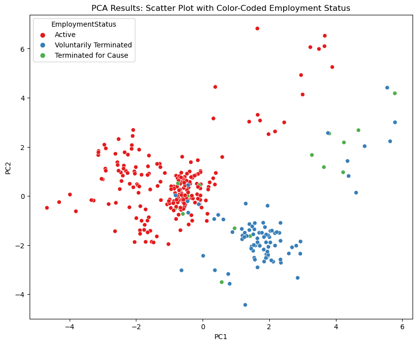

```python
pca_df = pd.DataFrame(data=pca_result, columns=[f'PC{i+1}' for i in range(pca_result.shape[1])])
pca_df['EmploymentStatus'] = df['EmploymentStatus']

plt.figure(figsize=(10, 8))
sns.scatterplot(data=pca_df, x='PC1', y='PC2', hue='EmploymentStatus', palette='Set1')
plt.title('PCA Results: Scatter Plot with Color-Coded Employment Status')
plt.show()
```

### 3. Identify the features most strongly represented in each component:</h3 >

```python
component_features = pd.DataFrame(pca.components_.T, columns=[f'PC{i+1}' for i in range(pca_result.shape[1])])
abs_component_features = component_features.abs()
top_features = abs_component_features.idxmax(axis=0)
```

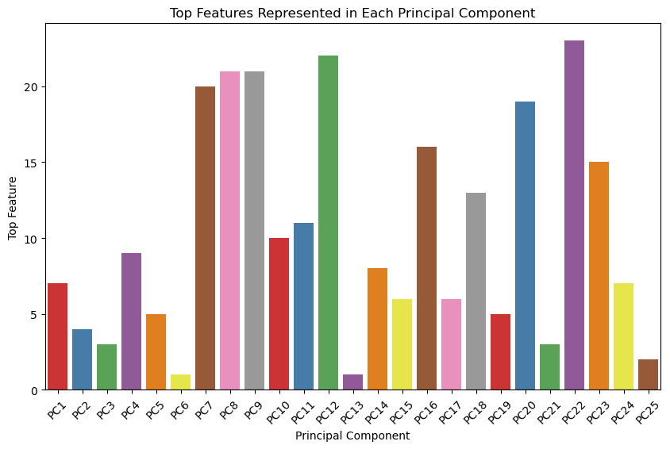

```python
plt.figure(figsize=(10, 6))
sns.barplot(data=top_features.reset_index(), x='index', y=0, palette='Set1')
plt.title('Top Features Represented in Each Principal Component')
plt.xlabel('Principal Component')
plt.ylabel('Top Feature')
plt.xticks(rotation=45)
plt.show()
```

#### The most effective features for separating employees by their employment status:

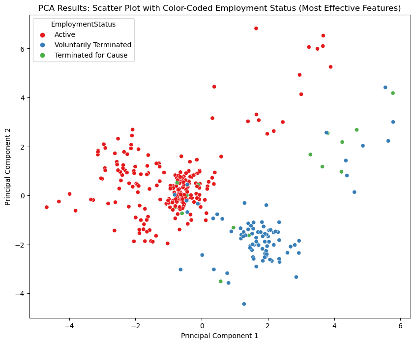

```python
# Visualize resulting clusters using top-ranked principal components
plt.figure(figsize=(10, 8))
sns.scatterplot(data=pca_df, x='PC1', y='PC2', hue=df['EmploymentStatus'], palette='Set1')
plt.title('PCA Results: Scatter Plot with Color-Coded Employment Status (Most Effective Features)')
plt.xlabel('Principal Component 1')
plt.ylabel('Principal Component 2')
plt.show()
```

This code will plot a scatter plot where each point represents an employee, and the color of the point will indicate their employment status. The principal components PC1 and PC2, which are among the most effective features in separating the employees, will be used as the x and y axes, respectively.

By visualizing the resulting clusters, you can observe how the most effective features contribute to the differentiation of employees based on their employment status. These features have a strong influence on the separation, leading to more distinct clusters for different employment statuses.

#### The least effective features for separating employees by their employment status:

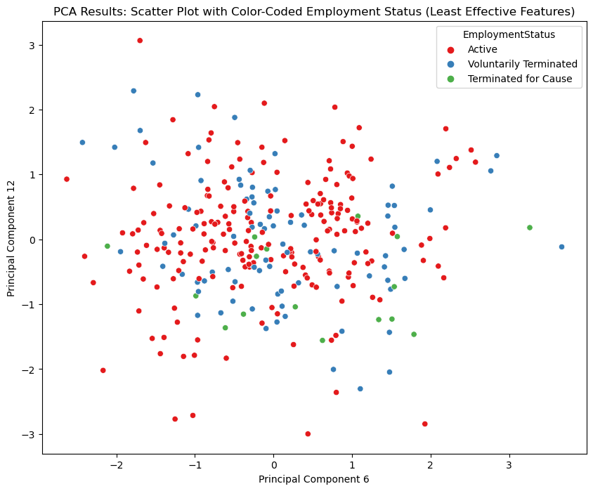

```python
# Visualize resulting clusters using lower-ranked principal components
plt.figure(figsize=(10, 8))
sns.scatterplot(data=pca_df, x='PC6', y='PC12', hue=df['EmploymentStatus'], palette='Set1')
plt.title('PCA Results: Scatter Plot with Color-Coded Employment Status (Least Effective Features)')
plt.xlabel('Principal Component 6')
plt.ylabel('Principal Component 12')
plt.show()
```

This code will plot a scatter plot where each point represents an employee, and the color of the point will indicate their employment status. The principal components PC6 and PC12, which are among the least effective features in separating the employees, will be used as the x and y axes, respectively.

By visualizing the resulting clusters, you can observe how the least effective features contribute to the differentiation of employees based on employment status. However, since these features have less impact on the separation, the clusters might overlap more, making it harder to distinguish between different employment statuses.

### Assign numeric codes to EmploymentStatus variable:

```python
df['EmploymentStatus'] = df['EmploymentStatus'].astype('category').cat.codes
```

### Find the most effective feature:

```python
# Perform PCA on the dataset
pca = PCA(n_components=2)
pca_result = pca.fit_transform(df)

# Calculate feature importance in each principal component
component_features = pd.DataFrame(pca.components_.T, columns=[f'PC{i+1}' for i in range(pca_result.shape[1])])
feature_importance = component_features.abs().mean(axis=1)

# Identify the feature with the highest importance
most_effective_feature = feature_importance.idxmax()
most_effective_feature_ = df.columns[7]
print(most_effective_feature_)
```

[output not shown]

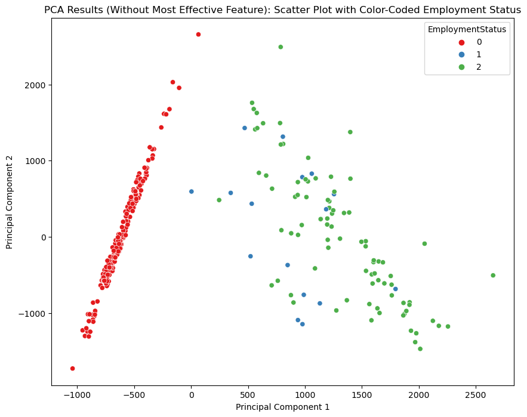

```
Remaining Features: Index(['MarriedID', 'MaritalStatusID', 'GenderID', 'DeptID', 'PerfScoreID',
       'FromDiversityJobFairID', 'Termd', 'PositionID', 'Sex', 'CitizenDesc',
       'HispanicLatino', 'RaceDesc', 'EmploymentStatus', 'ManagerID',
       'RecruitmentSource', 'PerformanceScore', 'EngagementSurvey',
       'EmpSatisfaction', 'SpecialProjectsCount', 'DaysLateLast30', 'Absences',
       'AgeAtHire', 'EmploymentDuration', 'TimeSinceLastReview',
       'TimeUntilTermination'],
      dtype='object')
```

```python
# Exclude the most effective feature from the dataset
modified_df = df.drop(columns=df.columns[most_effective_feature])

# Apply PCA on the modified dataset
pca_modified = PCA(n_components=2)
pca_result_modified = pca_modified.fit_transform(modified_df)

# Visualize the resulting clusters
plt.figure(figsize=(10, 8))
sns.scatterplot(data=pd.DataFrame(pca_result_modified, columns=['PC1', 'PC2']), x='PC1', y='PC2', hue=df['EmploymentStatus'], palette='Set1')
plt.title('PCA Results (Without Most Effective Feature): Scatter Plot with Color-Coded Employment Status')
plt.xlabel('Principal Component 1')
plt.ylabel('Principal Component 2')
plt.show()

# Explore the features most effective in separation (excluding the most effective feature)
remaining_features = modified_df.columns
print("Remaining Features:", remaining_features)
```

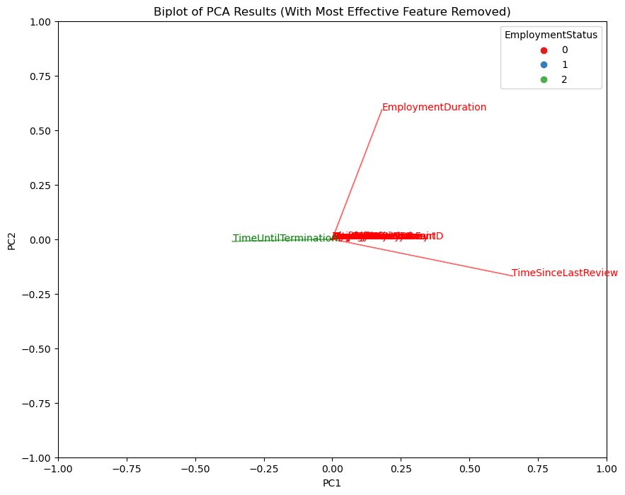

```python
# Apply PCA on the modified dataset
pca_modified = PCA(n_components=2)
pca_result_modified = pca_modified.fit_transform(modified_df)

# Create a DataFrame for the modified PCA results
pca_df_modified = pd.DataFrame(data=pca_result_modified, columns=['PC1', 'PC2'])

# Get the explained variance ratio for PC1 and PC2
explained_variance_ratio_modified = pca_modified.explained_variance_ratio_

# Create a biplot (with the most effective feature)
plt.figure(figsize=(10, 8))

# Plot the data points
sns.scatterplot(data=pca_df_modified, x='PC1', y='PC2', hue=df['EmploymentStatus'], palette='Set1', alpha=0.6)

# Plot the variable vectors
for i, feature in enumerate(modified_df.columns[:-1]):
    arrow_length = np.sqrt(explained_variance_ratio_modified[0]) * pca_modified.components_[0, i]
    arrow_width = np.sqrt(explained_variance_ratio_modified[1]) * pca_modified.components_[1, i]
    plt.arrow(0, 0, arrow_length, arrow_width, color='r', alpha=0.5)
    plt.text(arrow_length, arrow_width, feature, color='r')

# Plot the most effective feature vector
arrow_length = np.sqrt(explained_variance_ratio_modified[0]) * pca_modified.components_[0, -1]
arrow_width = np.sqrt(explained_variance_ratio_modified[1]) * pca_modified.components_[1, -1]
plt.arrow(0, 0, arrow_length, arrow_width, color='g', alpha=0.5)
plt.text(arrow_length, arrow_width, modified_df.columns[-1], color='g')

# Set the limits of the plot
plt.xlim(-1, 1)
plt.ylim(-1, 1)

# Set labels and title
plt.xlabel('PC1')
plt.ylabel('PC2')
plt.title('Biplot of PCA Results (With Most Effective Feature Removed)')

# Show the plot
plt.show()
```

The biplot will provide insights into the relationships between the data points and variables. Here are some aspects to consider when interpreting the biplot:

Angle and direction of vectors: The vectors represent the variables/features in the biplot. The angle between two vectors indicates the correlation between the corresponding features. Vectors pointing in the same direction or opposite directions indicate positive or negative correlations, respectively.

Variables' contribution: The length of the vectors represents the contribution of the variables to the principal components. Longer vectors indicate higher importance in explaining the data's variance. By examining the lengths and orientations of the vectors, you can identify the variables that have the most significant influence on PC1 and PC2.

By considering these aspects and analyzing the biplot, you can gain insights into the relationships between data points and variables, identify patterns, and understand the variables' contributions to the separation of different employment status groups.

### 5. Bonus:</h3 >

```python
# Perform PCA on the dataset
pca = PCA(n_components=2)
pca_result = pca.fit_transform(df)

# Calculate the coordinates of each data point in the PCA space
pca_df = pd.DataFrame(data=pca_result, columns=['PC1', 'PC2'])

# Calculate the Euclidean distance of each data point from the centroid in the PCA space
centroid = pca_df.mean()
distances = np.linalg.norm(pca_df - centroid, axis=1)

# Define a threshold value to determine outliers
threshold = np.percentile(distances, 95)  # Adjust the percentile as needed

# Identify the outliers
outliers = df[distances > threshold]

# Print the list of outliers
print(outliers)

# Explain the findings
print("Number of outliers:", len(outliers))
print("Threshold:", threshold)
```

```
     MarriedID  MaritalStatusID  GenderID  DeptID  PerfScoreID  \
18           0                0         0       3            3
42           1                1         1       3            3
55           0                0         1       5            4
76           0                0         1       3            4
96           0                0         1       3            4
108          0                0         0       3            3
131          1                1         0       6            3
150          1                1         0       2            3
190          1                1         1       3            2
212          0                0         1       4            4
239          0                0         0       3            3
240          0                0         0       3            3
243          0                0         1       3            3
244          0                2         1       3            3
```

[output cut: 78 more lines]

In this code, df represents your original dataset. The code calculates the Euclidean distances of each data point from the centroid in the PCA space. The threshold is defined as the 95th percentile of the distances, which can be adjusted as per your requirements. The code then identifies the data points that exceed the threshold as outliers and prints the list of outliers.

By analyzing the outliers, you can observe if they have any common characteristics or patterns that differentiate them from the rest of the data points. This analysis can provide insights into potential anomalies or peculiarities in your dataset.

# Section C (Classification):

### Split the dataset into features (X) and target variable (y):</h3 >

```python
X = df.drop('EmploymentStatus', axis=1)
y = df['EmploymentStatus']
```

### Split the data into training and testing sets:</h3 >

```python
X_train, X_test, y_train, y_test = train_test_split(X, y, test_size=0.2, random_state=42)
```

## Random Forest Classifier:

### Create a Random Forest classifier and perform parameter tuning using GridSearchCV:</h3 >

```python
# Create the Random Forest classifier
rf = RandomForestClassifier(random_state=42)

# Define the parameter grid for tuning
param_grid = {
    'n_estimators': [100, 200, 300],
    'max_depth': [None, 5, 10],
    'min_samples_split': [2, 5, 10],
    'min_samples_leaf': [1, 2, 4]
}

# Perform grid search to find the best parameters
grid_search = GridSearchCV(rf, param_grid, cv=5)
grid_search.fit(X_train, y_train)

# Get the best parameter values
best_params = grid_search.best_params_
best_params
```

```
{'max_depth': None,
 'min_samples_leaf': 1,
 'min_samples_split': 5,
 'n_estimators': 200}
```

### Train the Random Forest classifier with the best parameters:</h3 >

```python
# Create a new Random Forest classifier with the best parameters
rf_best = RandomForestClassifier(random_state=42, **best_params)

# Fit the classifier to the training data
rf_best.fit(X_train, y_train)
```

```
RandomForestClassifier(min_samples_split=5, n_estimators=200, random_state=42)
```

### Get feature importances using Random Forest and explain their significance::</h3 >

```python
# Get feature importances
importances = rf_best.feature_importances_

# Create a dataframe to store feature importances
feature_importances = pd.DataFrame({'Feature': X_train.columns, 'Importance': importances})

# Sort the features by importance in descending order
feature_importances = feature_importances.sort_values(by='Importance', ascending=False)

# Print the feature importances
print(feature_importances)
```

```
                   Feature  Importance
24    TimeUntilTermination    0.282077
23     TimeSinceLastReview    0.278856
7                    Termd    0.251752
16        EngagementSurvey    0.024534
22      EmploymentDuration    0.022366
13               ManagerID    0.021174
6                   Salary    0.016125
19          DaysLateLast30    0.013537
14       RecruitmentSource    0.012429
8               PositionID    0.012173
20                Absences    0.010548
21               AgeAtHire    0.010124
18    SpecialProjectsCount    0.008907
15        PerformanceScore    0.008434
4              PerfScoreID    0.007148
3                   DeptID    0.004572
1          MaritalStatusID    0.003570
17         EmpSatisfaction    0.003263
0                MarriedID    0.001891
10             CitizenDesc    0.001606
5   FromDiversityJobFairID    0.001384
12                RaceDesc    0.001174
2                 GenderID    0.000991
9                      Sex    0.000987
11          HispanicLatino    0.000378
```

### Compute accuracy for the model and provide sensitivity and specificity measurements for every class :</h3 >

```python
# Predict the employment status using the trained random forest Classifier
y_pred = rf_best.predict(X_test)

# Compute accuracy
accuracy_rf = accuracy_score(y_test, y_pred)

# Compute sensitivity and specificity for each class
class_labels = rf_best.classes_
sensitivity = {}
specificity = {}

for label in class_labels:
    label_index = np.where(class_labels == label)[0][0]
    true_positive = np.sum((y_test == label) & (y_pred == label))
    false_negative = np.sum((y_test == label) & (y_pred != label))
    true_negative = np.sum((y_test != label) & (y_pred != label))
    false_positive = np.sum((y_test != label) & (y_pred == label))
    sensitivity[label] = true_positive / (true_positive + false_negative)
    specificity[label] = true_negative / (true_negative + false_positive)

# Print accuracy, sensitivity, and specificity for each class
for label in class_labels:
    print(f"Class: {label}")
    print(f"Accuracy: {accuracy_rf:.4f}")
    print(f"Sensitivity: {sensitivity[label]:.4f}")
    print(f"Specificity: {specificity[label]:.4f}")
    print()
```

```
Class: 0
Accuracy: 0.9524
Sensitivity: 1.0000
Specificity: 1.0000

Class: 1
Accuracy: 0.9524
Sensitivity: 0.2500
Specificity: 1.0000

Class: 2
Accuracy: 0.9524
Sensitivity: 1.0000
Specificity: 0.9333
```

The above code performs parameter tuning using GridSearchCV to find the best combination of hyperparameters for the Random Forest classifier. Then, it trains the classifier using the best parameters and computes the feature importances.

The feature importances indicate the relative importance of each feature in predicting the target variable. Higher values indicate greater importance. By analyzing the feature importances, you can identify which features have a stronger influence on the model's predictions. It helps you understand which variables are more relevant in determining the employment status.

## Support Vector Machine:

### Create an SVM classifier and perform parameter tuning using GridSearchCV:</h3 >

```python
# Create the SVM classifier
svm = SVC(random_state=42)

# Define the parameter grid for tuning
param_grid = {
    'C': [0.1, 1, 10],
    'kernel': ['linear', 'rbf'],
    'gamma': ['scale', 'auto']
}

# Perform grid search to find the best parameters
grid_search = GridSearchCV(svm, param_grid, cv=5)
grid_search.fit(X_train, y_train)

# Get the best parameter values
best_params = grid_search.best_params_
best_params
```

```
{'C': 0.1, 'gamma': 'scale', 'kernel': 'linear'}
```

### Train the SVM classifier with the best parameters:</h3 >

```python
# Create a new SVM classifier with the best parameters
svm_best = SVC(random_state=42, **best_params)

# Fit the classifier to the training data
svm_best.fit(X_train, y_train)
```

```
SVC(C=0.1, kernel='linear', random_state=42)
```

### Compute accuracy for the model and provide sensitivity and specificity measurements for every class :</h3 >

```python
# Predict the employment status using the trained svm Classifier
y_pred = svm_best.predict(X_test)

# Compute accuracy
accuracy_svc = accuracy_score(y_test, y_pred)

# Compute sensitivity and specificity for each class
class_labels = rf_best.classes_
sensitivity = {}
specificity = {}

for label in class_labels:
    label_index = np.where(class_labels == label)[0][0]
    true_positive = np.sum((y_test == label) & (y_pred == label))
    false_negative = np.sum((y_test == label) & (y_pred != label))
    true_negative = np.sum((y_test != label) & (y_pred != label))
    false_positive = np.sum((y_test != label) & (y_pred == label))
    sensitivity[label] = true_positive / (true_positive + false_negative)
    specificity[label] = true_negative / (true_negative + false_positive)

# Print accuracy, sensitivity, and specificity for each class
for label in class_labels:
    print(f"Class: {label}")
    print(f"Accuracy: {accuracy_svc:.4f}")
    print(f"Sensitivity: {sensitivity[label]:.4f}")
    print(f"Specificity: {specificity[label]:.4f}")
    print()
```

```
Class: 0
Accuracy: 0.9365
Sensitivity: 1.0000
Specificity: 1.0000

Class: 1
Accuracy: 0.9365
Sensitivity: 0.5000
Specificity: 0.9661

Class: 2
Accuracy: 0.9365
Sensitivity: 0.8889
Specificity: 0.9556
```

## Gradient Boosting Classifier:

### Create a Gradient Boosting Classifier and perform parameter tuning using GridSearchCV:</h3 >

```python
# Create the Gradient Boosting Classifier
gbc = GradientBoostingClassifier(random_state=42)

# Define the parameter grid for tuning
param_grid = {
    'learning_rate': [0.1, 0.5, 1],
    'n_estimators': [50, 100, 200],
    'max_depth': [3, 5, 7]
}

# Perform grid search to find the best parameters
grid_search = GridSearchCV(gbc, param_grid, cv=5)
grid_search.fit(X_train, y_train)

# Get the best parameter values
best_params = grid_search.best_params_
best_params
```

```
{'learning_rate': 0.5, 'max_depth': 3, 'n_estimators': 100}
```

### Train the Gradient Boosting Classifier with the best parameters:</h3 >

```python
# Create a new Gradient Boosting Classifier with the best parameters
gbc_best = GradientBoostingClassifier(random_state=42, **best_params)

# Fit the classifier to the training data
gbc_best.fit(X_train, y_train)
```

```
GradientBoostingClassifier(learning_rate=0.5, random_state=42)
```

### Compute accuracy for the model and provide sensitivity and specificity measurements for every class :</h3 >

```python
# Predict the employment status using the trained Gradient Boosting Classifier
y_pred = gbc_best.predict(X_test)

# Compute accuracy
accuracy_gbc = accuracy_score(y_test, y_pred)

# Compute sensitivity and specificity for each class
class_labels = rf_best.classes_
sensitivity = {}
specificity = {}

for label in class_labels:
    label_index = np.where(class_labels == label)[0][0]
    true_positive = np.sum((y_test == label) & (y_pred == label))
    false_negative = np.sum((y_test == label) & (y_pred != label))
    true_negative = np.sum((y_test != label) & (y_pred != label))
    false_positive = np.sum((y_test != label) & (y_pred == label))
    sensitivity[label] = true_positive / (true_positive + false_negative)
    specificity[label] = true_negative / (true_negative + false_positive)

# Print accuracy, sensitivity, and specificity for each class
for label in class_labels:
    print(f"Class: {label}")
    print(f"Accuracy: {accuracy_gbc:.4f}")
    print(f"Sensitivity: {sensitivity[label]:.4f}")
    print(f"Specificity: {specificity[label]:.4f}")
    print()
```

```
Class: 0
Accuracy: 0.9206
Sensitivity: 1.0000
Specificity: 1.0000

Class: 1
Accuracy: 0.9206
Sensitivity: 0.5000
Specificity: 0.9492

Class: 2
Accuracy: 0.9206
Sensitivity: 0.8333
Specificity: 0.9556
```

### Obtain the feature importance from a trained Gradient Boosting Classifier:</h3 >

```python
# Train the Gradient Boosting Classifier with the best parameters (assuming gbc_best is already trained)
gbc_best.fit(X_train, y_train)

# Get feature importance scores
feature_importance = gbc_best.feature_importances_

# Create a dictionary to store feature importance scores with corresponding feature names
importance_dict = {feature: importance for feature, importance in zip(X.columns, feature_importance)}

# Sort the feature importance scores in descending order
sorted_importance = sorted(importance_dict.items(), key=lambda x: x[1], reverse=True)

# Display feature importance scores
for feature, importance in sorted_importance:
    print(f"{feature}: \t{importance}")
```

```
TimeSinceLastReview: 	0.4540968698912378
TimeUntilTermination: 	0.4145000809896252
EngagementSurvey: 	0.03190955006893112
EmploymentDuration: 	0.026467782003560827
Termd: 	0.02381732416831714
Salary: 	0.01966346301148855
PositionID: 	0.013886897577337064
AgeAtHire: 	0.006653270279196991
RecruitmentSource: 	0.004805240933436853
Absences: 	0.0030264448578457333
ManagerID: 	0.0009500512010532898
DeptID: 	0.00019079427836132264
SpecialProjectsCount: 	2.3332388883857895e-05
HispanicLatino: 	6.43832575253447e-06
MaritalStatusID: 	9.472581456192514e-07
EmpSatisfaction: 	9.458217961975859e-07
DaysLateLast30: 	5.542809330630451e-07
Sex: 	1.259239151668275e-08
CitizenDesc: 	3.4160603284144587e-11
MarriedID: 	2.8205621772115578e-11
PerfScoreID: 	9.338868158221302e-12
RaceDesc: 	1.940450127019775e-17
GenderID: 	0.0
FromDiversityJobFairID: 	0.0
PerformanceScore: 	0.0
```

The feature importances indicate the relative importance of each feature in predicting the target variable. Higher values indicate greater importance. By analyzing the feature importances, you can identify which features have a stronger influence on the model's predictions. It helps you understand which variables are more relevant in determining the employment status.

### Comparison of the model in terms of accuracy:</h3 >

```python
scores = pd.Series([accuracy_rf, accuracy_svc, accuracy_gbc,  ])
Model_Names = ['Random Forest Classifier','SVM Classifier','Gradient Boosting Classifier']
```

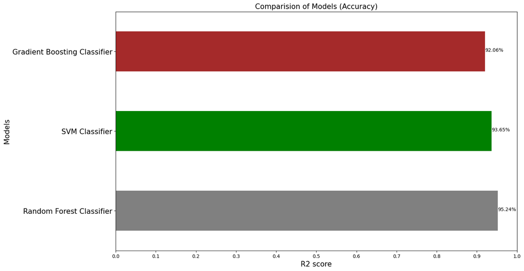

```python
ax = scores.plot(kind = 'barh',figsize=(15,9),color=['gray','green','brown','pink','blue','red'])
ax.set_title('Comparision of Models (Accuracy)',fontsize=15)
ax.set_xticks([0.0,0.1,0.2,0.3,0.4,0.5,0.6,0.7,0.8,0.9,1.0])
ax.set_yticklabels(Model_Names,fontsize=15,)
ax.set_ylabel("Models",fontsize=15)
ax.set_xlabel("R2 score",fontsize=15)
[ax.text(v, i, '{:.2f}%'.format(100*v)) for i, v in enumerate(scores)];
plt.show()
```

# Section D (Regression):

### Import the necessary Libraries for Regression:</h3 >

```python
import pandas as pd
from sklearn.model_selection import train_test_split
from sklearn.linear_model import LinearRegression
from sklearn.ensemble import RandomForestRegressor, GradientBoostingRegressor
from sklearn.metrics import mean_absolute_error, mean_squared_error, r2_score
from datetime import timedelta
```

### Split the dataset into features (X) and target variable (y):</h3 > The TimeUntilTermination is already calculate above from DateofTermination and LastPerformanceReview_Date.

```python
X = df.drop('TimeUntilTermination', axis=1)
y = df['TimeUntilTermination']
```

### Split the data into training and testing sets:</h3 >

```python
X_train, X_test, y_train, y_test = train_test_split(X, y, test_size=0.2, random_state=42)
```

## Random Forest Regressor:

### Create a Random Forest Regressor and perform parameter tuning using GridSearchCV:</h3 >

```python
# Create the Random Forest Regressor
rf = RandomForestRegressor(random_state=42)

# Define the parameter grid for tuning
param_grid = {
    'n_estimators': [100, 200, 300],
    'max_depth': [None, 5, 10],
    'min_samples_split': [2, 5, 10],
    'min_samples_leaf': [1, 2, 4]
}

# Perform grid search to find the best parameters
grid_search = GridSearchCV(rf, param_grid, cv=5)
grid_search.fit(X_train, y_train)

# Get the best parameter values
best_params = grid_search.best_params_
best_params
```

```
{'max_depth': None,
 'min_samples_leaf': 4,
 'min_samples_split': 10,
 'n_estimators': 300}
```

### Train the Random Forest Regressor with the best parameters:</h3 >

```python
# Create a new Random Forest Regressor with the best parameters
rf_best = RandomForestRegressor(random_state=42, **best_params)

# Fit the Regressor to the training data
rf_best.fit(X_train, y_train)
```

```
RandomForestRegressor(min_samples_leaf=4, min_samples_split=10,
                      n_estimators=300, random_state=42)
```

### Get feature importances using Random Forest and explain their significance::</h3 >

```python
# Get feature importances
importances = rf_best.feature_importances_

# Create a dataframe to store feature importances
feature_importances = pd.DataFrame({'Feature': X_train.columns, 'Importance': importances})

# Sort the features by importance in descending order
feature_importances = feature_importances.sort_values(by='Importance', ascending=False)

# Print the feature importances
print(feature_importances)
```

```
                   Feature  Importance
13        EmploymentStatus    0.454860
7                    Termd    0.396037
24     TimeSinceLastReview    0.129885
23      EmploymentDuration    0.006168
14               ManagerID    0.002254
21                Absences    0.002114
6                   Salary    0.001865
22               AgeAtHire    0.001118
17        EngagementSurvey    0.001066
3                   DeptID    0.000683
10             CitizenDesc    0.000647
15       RecruitmentSource    0.000581
8               PositionID    0.000521
18         EmpSatisfaction    0.000506
1          MaritalStatusID    0.000350
12                RaceDesc    0.000310
5   FromDiversityJobFairID    0.000278
20          DaysLateLast30    0.000252
0                MarriedID    0.000223
2                 GenderID    0.000078
19    SpecialProjectsCount    0.000062
9                      Sex    0.000058
4              PerfScoreID    0.000054
11          HispanicLatino    0.000015
16        PerformanceScore    0.000014
```

### Evaluate Random Forest Regressor using MAE, RMSE and R2 scores:</h3 >

```python
y_pred = rf_best.predict(X_test)
mean_absolute_error(y_pred, y_test)
print('\nMean Absolute Error:', mean_absolute_error(y_pred, y_test))
print('Root Mean Squared Error:', np.sqrt(mean_squared_error(y_pred, y_test)))
print('R2 score :', r2_score(y_pred, y_test))
```

```
Mean Absolute Error: 43.38053964712802
Root Mean Squared Error: 91.50751070428193
R2 score : 0.9620994673655205
```

# Linear Regression Model:

### Create a Linear Regression Model and train it on training set: </h3 >

```python
# Create the Linear Regression model
Lr = LinearRegression()
model_lr = Lr.fit(X_train, y_train)
y_pred = model_lr.predict(X_test)
```

### Evaluate Linear Regression model using MAE, RMSE and R2 scores:</h3 >

```python
y_pred = model_lr.predict(X_test)
mean_absolute_error(y_pred, y_test)
print('\nMean Absolute Error:', mean_absolute_error(y_pred, y_test))
print('Root Mean Squared Error:', np.sqrt(mean_squared_error(y_pred, y_test)))
print('R2 score :', r2_score(y_pred, y_test))
```

```
Mean Absolute Error: 66.80676107238526
Root Mean Squared Error: 99.47719653678247
R2 score : 0.9568176276262845
```

## Gradient Boosting Regressor:

### Create a Gradient Boosting regressor and perform parameter tuning using GridSearchCV:</h3 >

```python
# Create the Gradient Boosting Regressor
gbr = GradientBoostingRegressor(random_state=42)

# Define the parameter grid for tuning
param_grid = {
    'learning_rate': [0.1, 0.5, 1],
    'n_estimators': [50, 100, 200],
    'max_depth': [3, 5, 7]
}

# Perform grid search to find the best parameters
grid_search = GridSearchCV(gbr, param_grid, cv=5)
grid_search.fit(X_train, y_train)

# Get the best parameter values
best_params = grid_search.best_params_
best_params
```

```
{'learning_rate': 0.1, 'max_depth': 3, 'n_estimators': 50}
```

### Train the Gradient Boosting regressor with the best parameters:</h3 >

```python
# Create a new Gradient Boosting Regressor with the best parameters
gbr_best = GradientBoostingRegressor(random_state=42, **best_params)

# Fit the classifier to the training data
gbr_best.fit(X_train, y_train)
```

```
GradientBoostingRegressor(n_estimators=50, random_state=42)
```

### Obtain the feature importance from a trained Gradient Boosting regressor:</h3 >

```python
# Train the Gradient Boosting Regressor with the best parameters (assuming gbr_best is already trained)
gbr_best.fit(X_train, y_train)

# Get feature importance scores
feature_importance = gbr_best.feature_importances_

# Create a dictionary to store feature importance scores with corresponding feature names
importance_dict = {feature: importance for feature, importance in zip(X.columns, feature_importance)}

# Sort the feature importance scores in descending order
sorted_importance = sorted(importance_dict.items(), key=lambda x: x[1], reverse=True)

# Display feature importance scores
for feature, importance in sorted_importance:
    print(f"{feature}: \t{importance}")
```

```
EmploymentStatus: 	0.6707972305145762
Termd: 	0.3002432521091373
TimeSinceLastReview: 	0.007268161051847526
EmploymentDuration: 	0.006547285960554348
DeptID: 	0.003737772290699512
ManagerID: 	0.0026318126412453106
DaysLateLast30: 	0.0014975733931413603
Salary: 	0.00147108909464373
Absences: 	0.0011478487887006887
CitizenDesc: 	0.0009712726619059215
RaceDesc: 	0.0009557291830794313
RecruitmentSource: 	0.0007111559693962408
MaritalStatusID: 	0.0005448672412584865
AgeAtHire: 	0.00044450208948630616
EngagementSurvey: 	0.00034569345848166995
PositionID: 	0.0003418473024510636
PerformanceScore: 	0.00010742218492525613
FromDiversityJobFairID: 	9.410581457913739e-05
PerfScoreID: 	9.184394249165618e-05
SpecialProjectsCount: 	4.9417050220901125e-05
MarriedID: 	1.1725717787294e-07
GenderID: 	0.0
Sex: 	0.0
HispanicLatino: 	0.0
EmpSatisfaction: 	0.0
```

### Evaluate Regression model using MAE, RMSE and R2 scores:</h3 >

```python
y_pred = gbr_best.predict(X_test)
mean_absolute_error(y_pred, y_test)
print('\nMean Absolute Error:', mean_absolute_error(y_pred, y_test))
print('Root Mean Squared Error:', np.sqrt(mean_squared_error(y_pred, y_test)))
print('R2 score :', r2_score(y_pred, y_test))
```

```
Mean Absolute Error: 40.03239803442558
Root Mean Squared Error: 77.71043517573587
R2 score : 0.9726115670126408
```

### Post-process the results and find the exact termination date for each employee</h3 >

```python
predictions = gbr_best.predict(X)
# Calculate the exact termination date by adding the predicted time to the last performance review date
termination_dates = last_performance_dates + pd.to_timedelta(predictions, unit='D')

# Print the exact termination dates
for date in termination_dates:
    print(date)
```

```
2022-03-31 12:08:49.982956800
2016-07-01 15:18:04.971715200
2012-09-25 11:07:14.155046400
2022-02-26 21:39:15.687532800
2016-06-07 17:38:38.820710400
2022-03-09 10:50:54.523334400
2022-02-28 10:41:12.283670400
2022-06-14 11:52:15.164025600
2022-04-11 06:21:42.030374400
2022-05-31 18:31:47.443555200
2016-09-15 07:55:35.822294400
2016-10-28 05:33:39.993955200
2022-06-14 11:52:15.164025600
2022-05-23 21:38:18.785356800
2017-06-04 16:16:14.059372800
2017-09-19 22:44:34.952323200
2022-03-23 05:41:12.196953600
2022-03-25 16:13:44.009270400
2015-08-15 11:50:32.589427200
2022-03-17 08:09:55.691078400
2022-03-23 05:41:12.196953600
2022-03-15 08:07:07.982544
2022-06-18 04:29:27.597753600
2022-06-20 15:01:59.410070400
2014-10-26 06:26:47.803430400
2016-06-01 16:00:18.966038400
2022-05-31 18:31:47.443555200
2014-08-19 08:48:53.756035199
2013-09-14 05:40:34.377168
2022-03-22 08:18:29.194012800
2022-04-28 02:47:42.678988800
2022-04-06 02:08:35.124547200
2014-06-11 05:47:45.041078400
2022-06-06 17:44:19.186771200
2022-03-25 16:13:44.009270400
2022-04-08 12:41:06.936864
2022-06-08 16:30:08.474371200
2022-04-24 04:56:58.713849600
2022-04-28 02:47:42.678988800
2022-05-31 18:31:47.443555200
```

[output cut: 256 more lines]

```
2012-03-18 13:49:36.690153600
2015-09-19 17:49:17.175878400
2022-03-03 12:33:31.471315200
2022-05-07 01:38:58.986268800
2014-10-04 08:08:21.973776
2015-11-12 05:59:53.525356800
2011-12-25 05:44:49.323955200
2015-01-29 17:51:49.734432
2016-04-17 06:15:29.461564799
2022-06-06 17:44:19.186771200
2022-06-19 08:11:30.150643200
2016-01-30 11:16:09.764025600
2022-06-03 07:00:20.782684800
2022-04-28 02:47:42.678988800
2022-04-24 06:32:49.100496
```

# Section E (Bonus):

### Calculate the Employee Retention Rate for each year from 2008 until 2017 for every recruitment source and display it on a suitable graph:</h3 >

```python
df1 = pd.read_csv("Human_Resuorces_Analytics.csv")
```

```
No artists with labels found to put in legend.  Note that artists whose label start with an underscore are ignored when legend() is called with no argument.
```

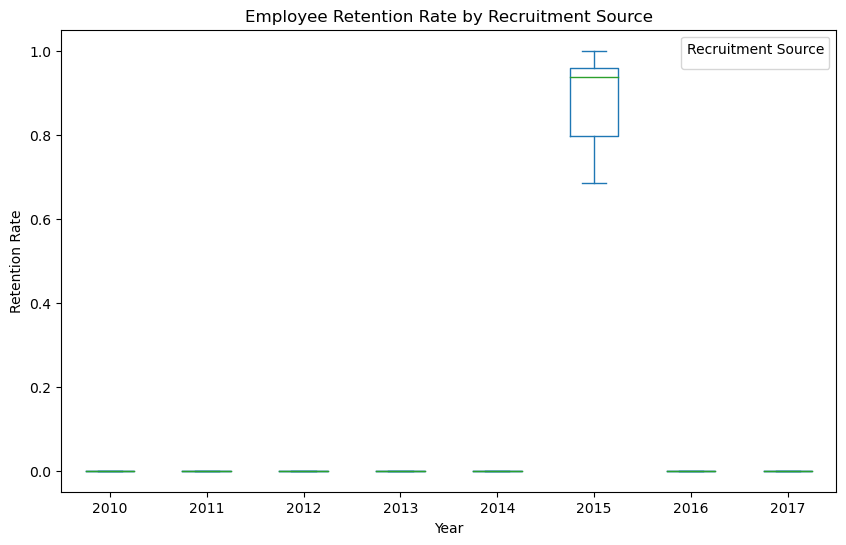

```python
import pandas as pd
import matplotlib.pyplot as plt

# Assuming you have already loaded the data into a DataFrame called 'df'
df1['DateofTermination'] = df1['DateofTermination'].fillna(df1['DateofTermination'].mode()[0])
# Filter the data for the years 2008 to 2017
df1['Year'] = pd.to_datetime(df1['DateofTermination']).dt.year
filtered_df = df1[df1['Year'].between(2008, 2017)]

# Calculate the retention rate for each recruitment source and year
retention_rates = filtered_df.groupby(['RecruitmentSource', 'Year']).apply(lambda x: 1 - x['Termd'].mean())

# Plot the retention rates on a graph
retention_rates.unstack().plot(kind='box', figsize=(10, 6))
plt.xlabel('Year')
plt.ylabel('Retention Rate')
plt.title('Employee Retention Rate by Recruitment Source')
plt.legend(title='Recruitment Source')
plt.show()
```

### Calculate the diversity index for each department based on race, gender, and age and display the department in descending order of their diversity index:</h3 >

```python
import pandas as pd

# Assuming you have already loaded the data into a DataFrame called 'df'
# Calculate age at hire
df1['DOB'] = pd.to_datetime(df1['DOB'])
df1['DateofHire'] = pd.to_datetime(df1['DateofHire'])
df1['AgeAtHire'] = (df1['DateofHire'] - df1['DOB']).dt.days // 365
# Calculate the diversity index
diversity_df = df1.groupby('Department').agg({'RaceDesc': lambda x: len(x.unique()), 'GenderID': lambda x: len(x.unique()), 'AgeAtHire': lambda x: len(x.unique())})
diversity_df['DiversityIndex'] = diversity_df['RaceDesc'] + diversity_df['GenderID'] + diversity_df['AgeAtHire']

# Sort departments in descending order of diversity index
diversity_df = diversity_df.sort_values('DiversityIndex', ascending=False)

# Display the departments and their diversity index
print(diversity_df[['DiversityIndex']])
```

```
                      DiversityIndex
Department
Production                        51
Sales                             28
IT/IS                             27
Software Engineering              12
Admin Offices                     11
Executive Office                   3
```

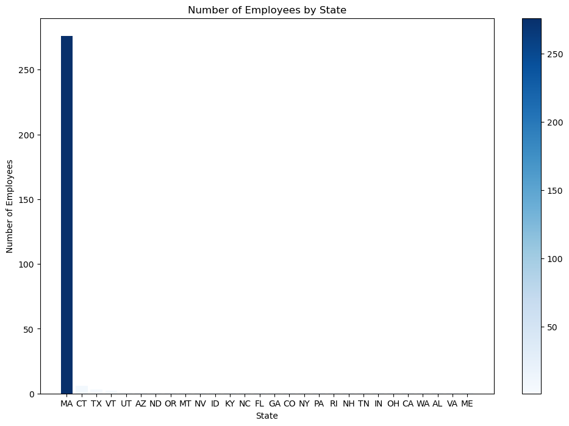

```python
import matplotlib.pyplot as plt

# Count the number of employees from each state
state_counts = df1['State'].value_counts()

# Read the state codes and corresponding counts into lists
state_codes = state_counts.index.tolist()
employee_counts = state_counts.values.tolist()

# Create a colormap for coloring the states
colormap = plt.cm.get_cmap('Blues')

# Plot the number of employees by state
fig, ax = plt.subplots(figsize=(12, 8))
bars = ax.bar(state_codes, employee_counts, color=colormap(employee_counts))

# Add labels and title
ax.set_xlabel('State')
ax.set_ylabel('Number of Employees')
ax.set_title('Number of Employees by State')

# Create a colorbar legend
sm = plt.cm.ScalarMappable(cmap=colormap, norm=plt.Normalize(vmin=min(employee_counts), vmax=max(employee_counts)))
sm.set_array([])
cbar = plt.colorbar(sm)

# Show the plot
plt.show()
```

# Section F (Performance - Bonus):

### Classification Task:</h3 >

```python
X = df.drop('EmploymentStatus', axis=1)
y = df['EmploymentStatus']

X_train, X_test, y_train, y_test = train_test_split(X, y, test_size=0.2, random_state=42)

# Create a new Random Forest classifier with the best parameters
rf_best = RandomForestClassifier(random_state=42, )

# Fit the classifier to the training data
rf_best.fit(X_train, y_train)

# Predict the employment status using the trained random forest Classifier
y_pred = rf_best.predict(X_test)


from sklearn.metrics import accuracy_score, precision_score, recall_score, f1_score, roc_auc_score

# Assuming you have your true labels and predicted labels stored in y_true and y_pred, respectively

# Calculate accuracy
accuracy = accuracy_score(y_test, y_pred)

# Calculate precision
precision = precision_score(y_test, y_pred, average='weighted')

# Calculate recall
recall = recall_score(y_test, y_pred, average='weighted')

# Calculate F1 score
f1 = f1_score(y_test, y_pred, average='weighted')

y_pred_prob = rf_best.predict_proba(X_test)
# Calculate AUC-ROC
auc_roc = roc_auc_score(y_test, y_pred_prob,  multi_class='ovr')



print('Accuracy: ', accuracy)
print('Precision: ', precision)
print('Recall: ', recall)
print('F1: ', recall)
print('Auc_Roc: ', auc_roc)
```

```
Accuracy:  0.9523809523809523
Precision:  0.9487607908660539
Recall:  0.9523809523809523
F1:  0.9523809523809523
Auc_Roc:  0.9704052451698403
```

### Regression Task:</h3 >

```python
X = df.drop('TimeUntilTermination', axis=1)
y = df['TimeUntilTermination']

X_train, X_test, y_train, y_test = train_test_split(X, y, test_size=0.2, random_state=42)

# Create a new Gradient Boosting Regressor with the best parameters
gbr_best = GradientBoostingRegressor(random_state=42, **best_params)

# Fit the classifier to the training data
gbr_best.fit(X_train, y_train)

# Predict the employment status using the trained model
y_pred = gbr_best.predict(X_test)


from sklearn.metrics import mean_absolute_error, mean_squared_error, r2_score

# Assuming you have your true values and predicted values stored in y_true and y_pred, respectively

# Calculate mean absolute error
mae = mean_absolute_error(y_test, y_pred)

# Calculate mean squared error
mse = mean_squared_error(y_test, y_pred)

# Calculate root mean squared error
rmse = np.sqrt(mse)

# Calculate R-squared
r2 = r2_score(y_test, y_pred)


print('MAE: ', mae)
print('MSE: ', mse)
print('RMSE: ', rmse)
print('R2: ', r2)
```

```
MAE:  40.03239803442558
MSE:  6038.911735202247
RMSE:  77.71043517573587
R2:  0.9734915883138399
```